# HW Week 11

Md Ariful Haque Miah, Ayodegi

11/13/2022

Problem 6.8

```r
time<-c(rep(-1, 12),rep(1, 12) )
cul_med<-c(rep(-1, 2), rep(1, 2))
obs <- c(21,22,25,26,23,28,24,25,20,26,29,27,37,39,31,34,38,38,29,33,35,36,30,35)
time <- as.factor(time)
cul_med <- as.factor(cul_med)
dat <- data.frame(time,cul_med,obs)
dat
```

| time | cul_med | obs |
| --- | --- | --- |
| -1 | -1 | 21 |
| -1 | -1 | 22 |
| -1 | 1 | 25 |
| -1 | 1 | 26 |
| -1 | -1 | 23 |
| -1 | -1 | 28 |
| -1 | 1 | 24 |
| -1 | 1 | 25 |
| -1 | -1 | 20 |
| -1 | -1 | 26 |

[output cut: 14 more lines]

```r
model <- aov(obs~time*cul_med,data=dat)
summary(model)
```

```
##              Df Sum Sq Mean Sq F value   Pr(>F)
## time          1  590.0   590.0 115.506 9.29e-10 ***
## cul_med       1    9.4     9.4   1.835 0.190617
## time:cul_med  1   92.0    92.0  18.018 0.000397 ***
## Residuals    20  102.2     5.1
## ---
## Signif. codes:  0 '***' 0.001 '**' 0.01 '*' 0.05 '.' 0.1 ' ' 1
```

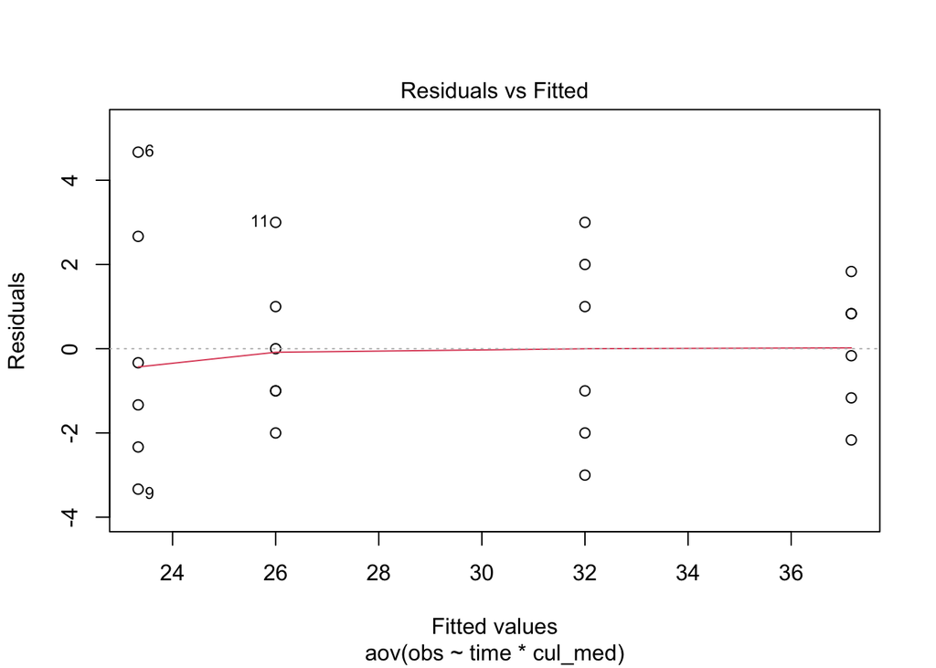

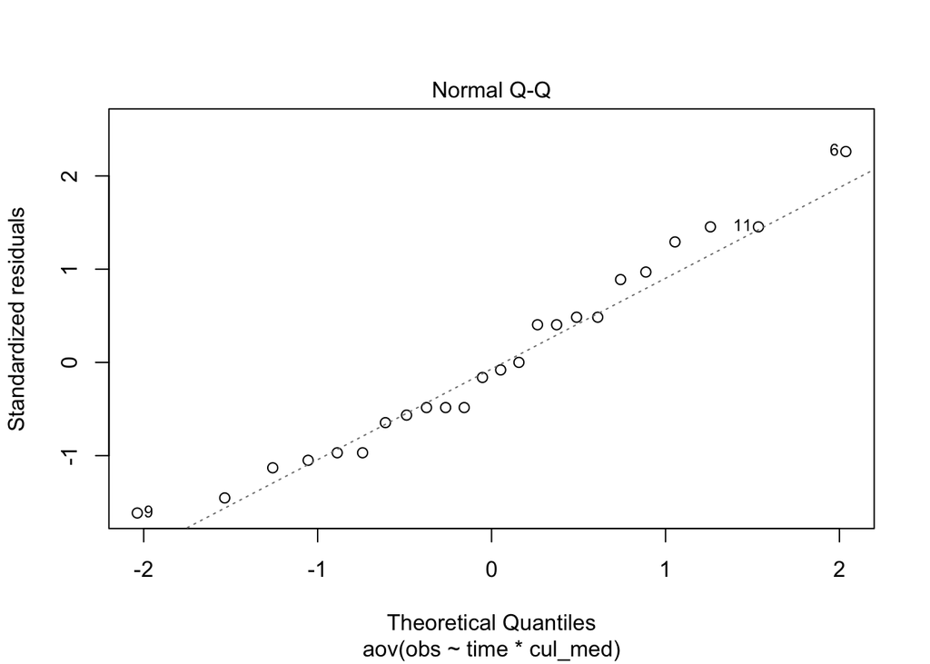

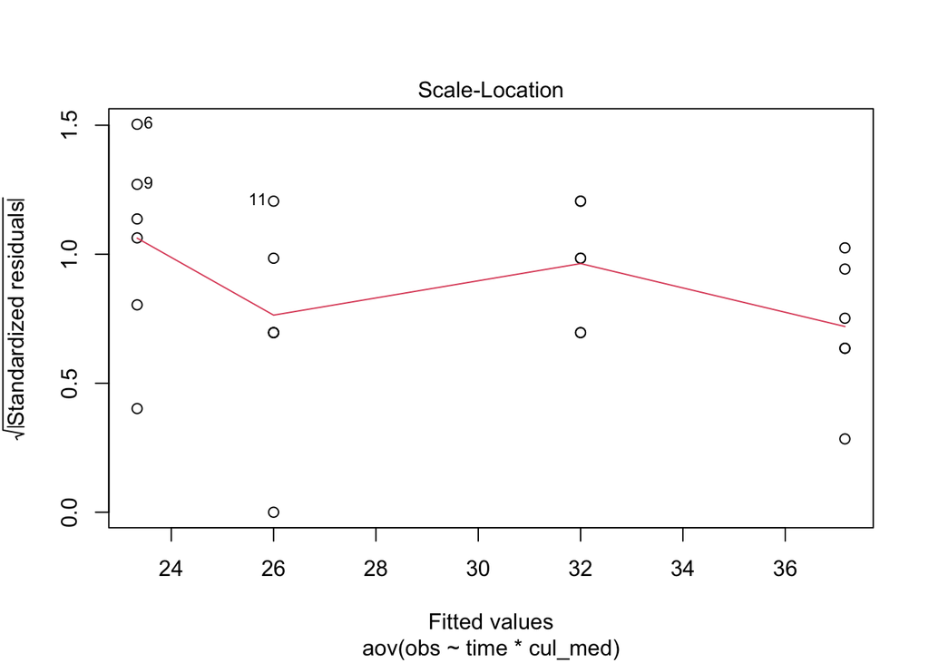

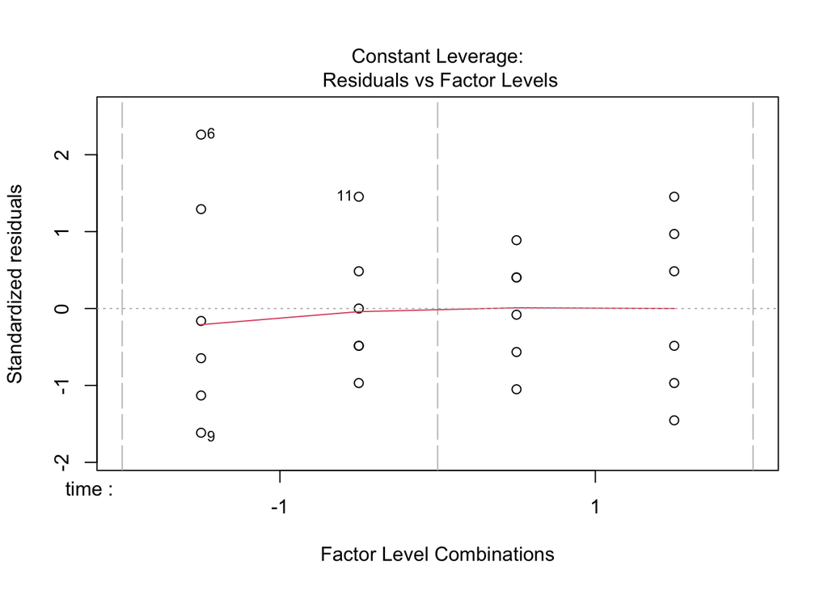

```r
plot(model)
```

Hypothesis Test:

$H_0: \alpha_i = 0$

$H_a: \alpha_i \neq 0$

$H_0: \beta_j\ = 0$

$H_a: \beta_j \neq 0$

$H_0: \alpha\beta_{ij}=0$

$H_a: \alpha\beta_{ij}\neq0$

Only the factors Time and the interaction effects (Time:Culture Medium) are significant as the p value is less than $\alpha=0.001$ level of significance so for these factors we reject $H_0$ and the factor Culture medium is not significant as the p value is larger than $\alpha=0.05$ level of significance so for this factors we fail to reject $H_0$. Also Residual vs Fitted plot shows that the variance is constant and the errors are normally distributed and thus the model is adequate.

Problem 6.12 (a) Estimate the factor effects

```r
A <- c(rep(-1,4),rep(1,4))
B <- c(rep(-1,8),rep(1,8))
obs <- c(14.037,16.165,13.972,13.907,13.880,13.860,14.032,13.914,14.821,14.757,14.843,14.878,14.888,14.921,14.415,14.932)
A <- as.factor(A)
B <- as.factor(B)
dat <- data.frame(A,B,obs)
dat
```

| A | B | obs |
| --- | --- | --- |
| -1 | -1 | 14.037 |
| -1 | -1 | 16.165 |
| -1 | -1 | 13.972 |
| -1 | -1 | 13.907 |
| 1 | -1 | 13.880 |
| 1 | -1 | 13.860 |
| 1 | -1 | 14.032 |
| 1 | -1 | 13.914 |
| -1 | 1 | 14.821 |
| -1 | 1 | 14.757 |

[output cut: 6 more lines]

Finding Corner Points:

```r
one <- sum(dat$obs[1:4])
one
```

```
## [1] 58.081
```

```r
a <- sum(dat$obs[5:8])
a
```

```
## [1] 55.686
```

```r
b <- sum(dat$obs[9:12])
b
```

```
## [1] 59.299
```

```r
ab <- sum(dat$obs[13:16])
ab
```

```
## [1] 59.156
```

```r
n <- c(4)
fact_A <- 2*(a+ab-b-one)/(4*n)
fact_A
```

```
## [1] -0.31725
```

```r
fact_B <- 2*(b+ab-a-one)/(4*n)
fact_B
```

```
## [1] 0.586
```

```r
fact_AB <- 2*(ab+one-a-b)/(4*n)
fact_AB
```

```
## [1] 0.2815
```

Therefore, The factor Effect A = -0.31725, B = 0.586, Interaction effect AB = 0.2815

2. Analysis of variance

```r
A <- c(rep(-1,4),rep(1,4))
B <- c(rep(-1,8),rep(1,8))
obs <- c(14.037,16.165,13.972,13.907,13.880,13.860,14.032,13.914,14.821,14.757,14.843,14.878,14.888,14.921,14.415,14.932)
A <- as.factor(A)
B <- as.factor(B)
dat <- data.frame(A,B,obs)
dat
```

| A | B | obs |
| --- | --- | --- |
| -1 | -1 | 14.037 |
| -1 | -1 | 16.165 |
| -1 | -1 | 13.972 |
| -1 | -1 | 13.907 |
| 1 | -1 | 13.880 |
| 1 | -1 | 13.860 |
| 1 | -1 | 14.032 |
| 1 | -1 | 13.914 |
| -1 | 1 | 14.821 |
| -1 | 1 | 14.757 |

[output cut: 6 more lines]

```r
model <- aov(obs~A*B,data=dat)
summary(model)
```

```
##             Df Sum Sq Mean Sq F value Pr(>F)
## A            1  0.403  0.4026   1.262 0.2833
## B            1  1.374  1.3736   4.305 0.0602 .
## A:B          1  0.317  0.3170   0.994 0.3386
## Residuals   12  3.828  0.3190
## ---
## Signif. codes:  0 '***' 0.001 '**' 0.01 '*' 0.05 '.' 0.1 ' ' 1
```

Hypothesis Test: $H_0: \alpha_i = 0$

$H_a: \alpha_i \neq 0$

$H_0: \beta_j\ = 0$

$H_a: \beta_j \neq 0$

$H_0: \alpha\beta_{ij}=0$

$H_a: \alpha\beta_{ij}\neq0$

p values of the main effect A and the interaction effect (A:B) is greater than $\alpha = 0.05$ level of significance. Hence the main effect A and the interaction effect (A:B) are not significant as we fail to reject $H_0$. On the other hand p value of the main effect B is less than $\alpha = 0.1$ level of significance. Hence the main effect B is significant as we reject $H_0$.

3. Regression Equation:

```r
A <- c(rep(-1,4),rep(1,4))
B <- c(rep(-1,8),rep(1,8))
obs <- c(14.037,16.165,13.972,13.907,13.880,13.860,14.032,13.914,14.821,14.757,14.843,14.878,14.888,14.921,14.415,14.932)
A <- as.factor(A)
B <- as.factor(B)
dat <- data.frame(A,B,obs)
dat
```

| A | B | obs |
| --- | --- | --- |
| -1 | -1 | 14.037 |
| -1 | -1 | 16.165 |
| -1 | -1 | 13.972 |
| -1 | -1 | 13.907 |
| 1 | -1 | 13.880 |
| 1 | -1 | 13.860 |
| 1 | -1 | 14.032 |
| 1 | -1 | 13.914 |
| -1 | 1 | 14.821 |
| -1 | 1 | 14.757 |

[output cut: 6 more lines]

```r
model <- lm(obs~A+B+A*B,data=dat)
summary(model)
```

```
##
## Call:
## lm(formula = obs ~ A + B + A * B, data = dat)
##
## Residuals:
##      Min       1Q   Median       3Q      Max
## -0.61325 -0.14431 -0.00563  0.10188  1.64475
##
## Coefficients:
##             Estimate Std. Error t value Pr(>|t|)
## (Intercept)  14.5203     0.2824  51.414 1.93e-15 ***
## A1           -0.5988     0.3994  -1.499    0.160
## B1            0.3045     0.3994   0.762    0.461
## A1:B1         0.5630     0.5648   0.997    0.339
## ---
## Signif. codes:  0 '***' 0.001 '**' 0.01 '*' 0.05 '.' 0.1 ' ' 1
##
## Residual standard error: 0.5648 on 12 degrees of freedom
## Multiple R-squared:  0.3535, Adjusted R-squared:  0.1918
## F-statistic: 2.187 on 3 and 12 DF,  p-value: 0.1425
```

y = $\beta_0 + \beta_2 *x_2 + \epsilon$

4. The Residuals Analysis

```r
A <- c(rep(-1,4),rep(1,4))
B <- c(rep(-1,8),rep(1,8))
obs <- c(14.037,16.165,13.972,13.907,13.880,13.860,14.032,13.914,14.821,14.757,14.843,14.878,14.888,14.921,14.415,14.932)
A <- as.factor(A)
B <- as.factor(B)
dat <- data.frame(A,B,obs)
dat
```

| A | B | obs |
| --- | --- | --- |
| -1 | -1 | 14.037 |
| -1 | -1 | 16.165 |
| -1 | -1 | 13.972 |
| -1 | -1 | 13.907 |
| 1 | -1 | 13.880 |
| 1 | -1 | 13.860 |
| 1 | -1 | 14.032 |
| 1 | -1 | 13.914 |
| -1 | 1 | 14.821 |
| -1 | 1 | 14.757 |

[output cut: 6 more lines]

```r
model <- aov(obs~A*B,data=dat)
summary(model)
```

```
##             Df Sum Sq Mean Sq F value Pr(>F)
## A            1  0.403  0.4026   1.262 0.2833
## B            1  1.374  1.3736   4.305 0.0602 .
## A:B          1  0.317  0.3170   0.994 0.3386
## Residuals   12  3.828  0.3190
## ---
## Signif. codes:  0 '***' 0.001 '**' 0.01 '*' 0.05 '.' 0.1 ' ' 1
```

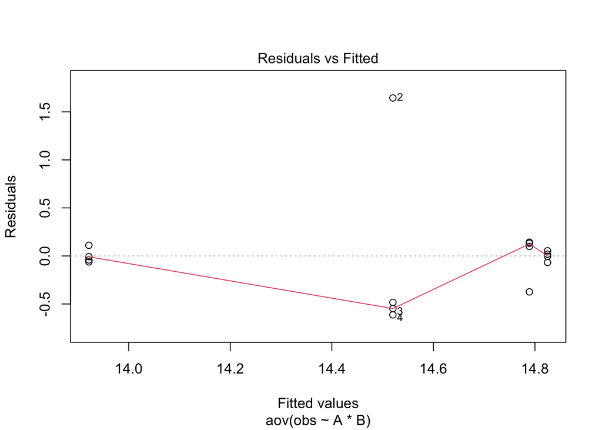

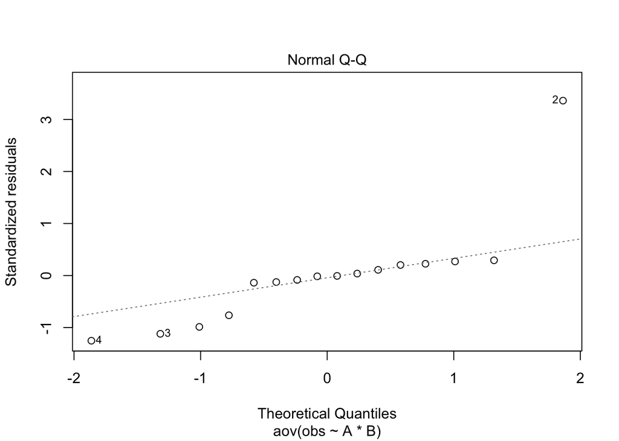

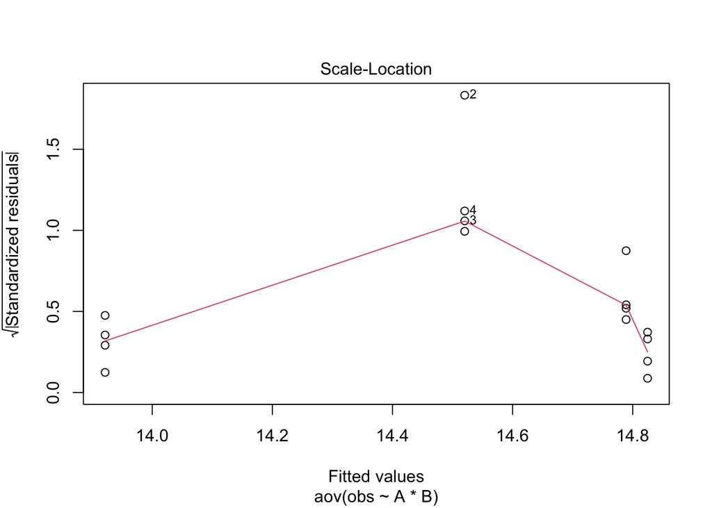

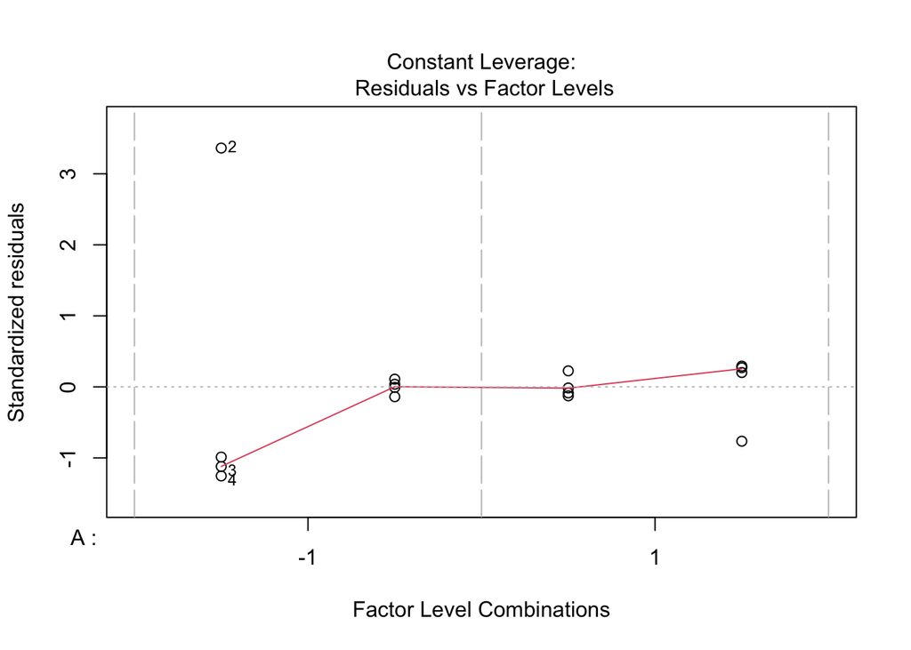

```r
plot(model)
```

5. The potential Outlier: Only the observation no. 2 might be the potential outlier according to the $\sqrt$(standardized residual) plot in part (d). Since There is 15 more observations left so only one outlier won’t cause any effect to grow an epitaxial layer on polished silicon wafers.

Problem 6.21 (a)

```r
A <- c(rep(-1,7),rep(1,7))
B <- c(rep(-1,14),rep(1,14))
C <- c(rep(-1,28),rep(1,28))
D <- c(rep(-1,56),rep(1,56))
obs <- c(10,18,14,12.5,19,16,18.5,0,16.5,4.5,17.5,20.5,17.5,33,4,6,1,14.5,12,14,5,0,10,34,11,25.5,21.5,0,0,0,18.5,19.5,16,15,11,
         5,20.5,18,20,29.5,19,10,6.5,18.5,7.5,6,0,10,0,16.5,4.5,0,23.5,8,8,8,4.5,18,14.5,10,0,17.5,6,19.5,18,16,5.5,10,7,
         36,15,16,8.5,0,0.5,9,3,41.5,39,6.5,3.5,7,8.5,36,8,4.5,6.5,10,13,41,14,21.5,10.5,6.5,0,15.5,24,16,0,0,0,4.5,1,4,6.5,18,
         5,7,10,32.5,18.5,8)
A <- as.factor(A)
B <- as.factor(B)
C <- as.factor(C)
D <- as.factor(D)
dat <- data.frame(A,B,C,D,obs)
dat
```

| A | B | C | D | obs |
| --- | --- | --- | --- | --- |
| -1 | -1 | -1 | -1 | 10.0 |
| -1 | -1 | -1 | -1 | 18.0 |
| -1 | -1 | -1 | -1 | 14.0 |
| -1 | -1 | -1 | -1 | 12.5 |
| -1 | -1 | -1 | -1 | 19.0 |
| -1 | -1 | -1 | -1 | 16.0 |
| -1 | -1 | -1 | -1 | 18.5 |
| 1 | -1 | -1 | -1 | 0.0 |
| 1 | -1 | -1 | -1 | 16.5 |
| 1 | -1 | -1 | -1 | 4.5 |

[output cut: 102 more lines]

```r
model <- aov(obs~A*B*C*D,data=dat)
summary(model)
```

```
##             Df Sum Sq Mean Sq F value  Pr(>F)
## A            1    917   917.1  10.588 0.00157 **
## B            1    388   388.1   4.481 0.03686 *
## C            1    145   145.1   1.676 0.19862
## D            1      1     1.4   0.016 0.89928
## A:B          1    219   218.7   2.525 0.11538
## A:C          1     12    11.9   0.137 0.71178
## B:C          1    115   115.0   1.328 0.25205
## A:D          1     94    93.8   1.083 0.30066
## B:D          1     56    56.4   0.651 0.42159
## C:D          1      2     1.6   0.019 0.89127
## A:B:C        1      7     7.3   0.084 0.77294
## A:B:D        1    113   113.0   1.305 0.25623
## A:C:D        1     39    39.5   0.456 0.50121
## B:C:D        1     34    33.8   0.390 0.53386
## A:B:C:D      1     96    95.6   1.104 0.29599
## Residuals   96   8316    86.6
## ---
## Signif. codes:  0 '***' 0.001 '**' 0.01 '*' 0.05 '.' 0.1 ' ' 1
```

Hypothesis Test:

$H_0: \alpha_i = 0$

$H_a: \alpha_i \neq 0$

$H_0: \beta_j\ = 0$

$H_a: \beta_j \neq 0$

$H_0: \gamma_k\ = 0$

$H_a: \gamma_k \neq 0$

$H_0: \delta_l\ = 0$

$H_a: \delta_l \neq 0$

$H_0: \alpha\beta_{ij}=0$

$H_a: \alpha\beta_{ij}\neq0$

$H_0: \alpha\gamma_{ik}=0$

$H_a: \alpha\gamma_{ik}\neq0$

$H_0: \alpha\delta_{il}=0$

$H_a: \alpha\delta_{il}\neq0$

…..

…..

…..

$H_0: \alpha\beta\gamma\delta_{ijkl}=0$

$H_a: \alpha\beta\gamma\delta_{ijkl}\neq0$

From the anova model summary and analyzing the p value we see that None of the interaction terms are significant but the main effect factors “length of putt” and “the type of putter” are significant and these factors significantly affect putting performance.

Problem 6.21 (b)

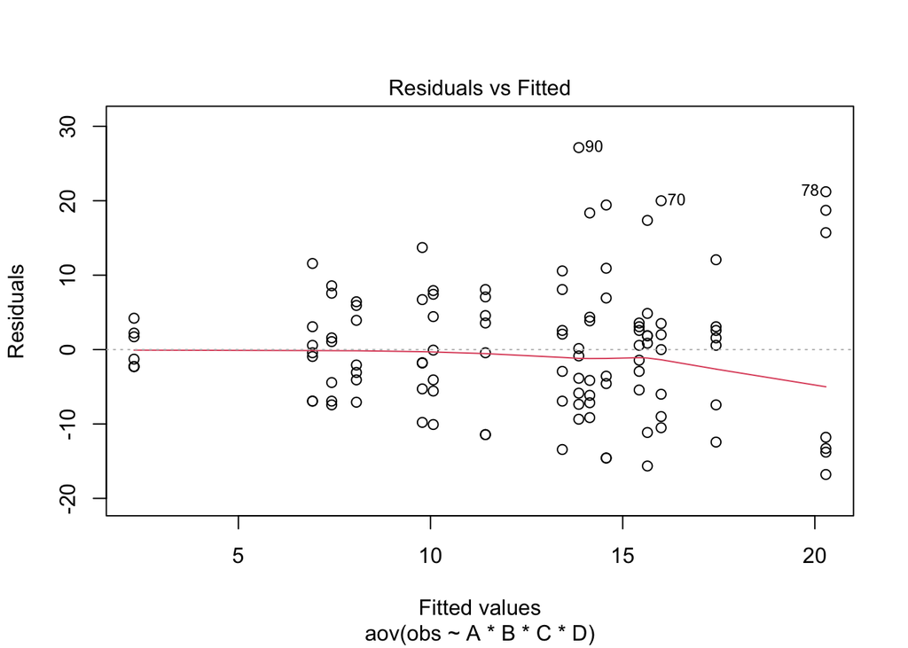

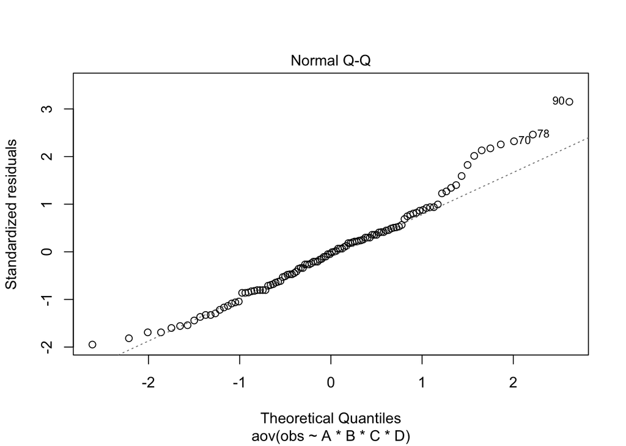

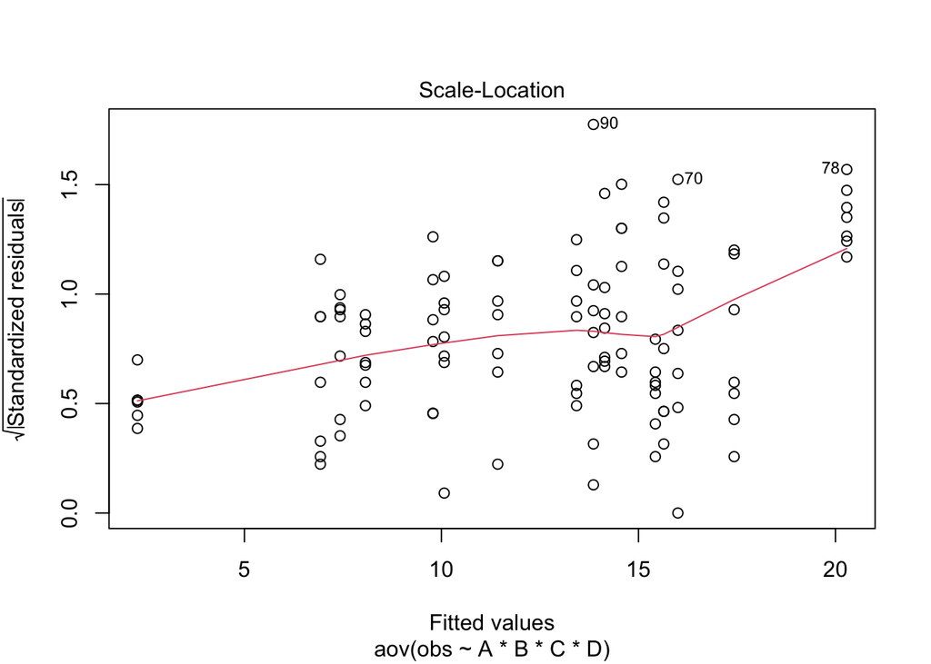

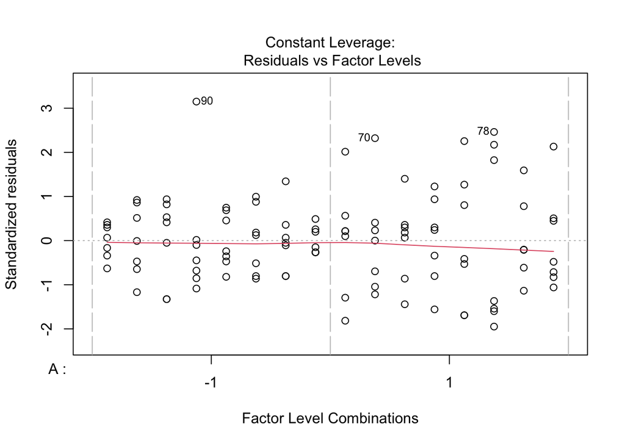

```r
plot(model)
```

Residual vs fitted plot shows that the variance is not constant and hence the model is not adequate though the errors are assumed to be normally distributed from the normal Q-Q plot.